# Using Logistic Regression for Machine Learning Predictions

Satya Vrat Singh

January 12, 2019

# Prediction of whether the individual belongs to low income group or high income group

### Abstract - Implementation

- Lower-income families may face unique challenges in health plans.
- This break point between lower and higher incomes can be chosen for the policy relevance as the threshold for subsidies under different categories (Healthcare,BPL card, etc).
- Those in higher-income households are more likely to use the internet on any given day, own multiple internet-ready devices, do things involving money online, and get news online
- Clear the environment

```r
rm(list=ls(all=TRUE))
```

# Agenda

- Get the data
- Data Pre-processing
- Build a model
- Predictions
- Analysis

# Reading & Understanding the Data

- Make sure the dataset is located in your current working directory

```r
population_dataset = read.csv("train_data.csv")
```

- Use the str(), summary() functions to get a feel for the dataset.

```r
str(population_dataset)
```

```
## 'data.frame':    31587 obs. of  18 variables:
##  $ index             : int  1 2 3 4 5 6 7 8 9 10 ...
##  $ age               : int  39 50 38 53 28 37 49 52 31 42 ...
##  $ working_sector    : Factor w/ 7 levels "local_body","national",..: 6 5 4 4 4 4 4 5 4 4 ...
##  $ financial_weight  : int  77516 83311 215646 234721 338409 284582 160187 209642 45781 159449 ...
##  $ qualification     : Factor w/ 16 levels " 10th"," 11th",..: 10 10 12 2 10 13 7 12 13 10 ...
##  $ years_of_education: int  13 13 9 7 13 14 5 9 14 13 ...
##  $ tax_paid          : num  NA NA NA NA NA ...
##  $ loan_taken        : int  0 0 0 0 0 0 0 1 0 0 ...
##  $ marital_status    : Factor w/ 7 levels "Divorced","Married-civilian",..: 5 2 1 2 2 2 4 2 5 2 ...
##  $ occupation        : Factor w/ 14 levels "cleaner","clerical",..: 2 8 1 1 12 8 9 8 12 8 ...
##  $ relationship      : Factor w/ 6 levels " Husband"," Not-in-family",..: 2 1 2 1 6 6 2 1 2 1 ...
##  $ ethnicity         : Factor w/ 5 levels " Amer-Indian-Eskimo",..: 5 5 5 3 3 5 3 5 5 5 ...
##  $ gender            : Factor w/ 2 levels " Female"," Male": 2 2 2 2 1 1 1 2 1 2 ...
##  $ gain              : int  2174 0 0 0 0 0 0 0 14084 5178 ...
##  $ loss              : int  0 0 0 0 0 0 0 0 0 0 ...
##  $ working_hours     : int  40 13 40 40 40 40 16 45 50 40 ...
##  $ country           : Factor w/ 41 levels " Cambodia"," Canada",..: 39 39 39 39 5 39 23 39 39 39 ...
##  $ target            : int  0 0 0 0 0 0 0 1 1 1 ...
```

- The dataset has 31587 observations of 18 variables.

```r
summary(population_dataset)
```

```
##      index            age              working_sector  financial_weight
##  Min.   :    1   Min.   :17.00   private      :22033   Min.   :  12285
##  1st Qu.: 7898   1st Qu.:28.00   self_employed: 3543   1st Qu.: 117881
##  Median :15794   Median :37.00   local_body   : 2019   Median : 178564
##  Mean   :15794   Mean   :38.56   state        : 1274   Mean   : 189976
##  3rd Qu.:23691   3rd Qu.:48.00   national     :  923   3rd Qu.: 237466
##  Max.   :31587   Max.   :90.00   (Other)      :   20   Max.   :1484705
##                  NA's   :2       NA's         : 1775   NA's   :2
##        qualification   years_of_education    tax_paid
##   HS-grad     :10198   Min.   : 1.00      Min.   :2010
##   Some-college: 7078   1st Qu.: 9.00      1st Qu.:5004
##   Bachelors   : 5196   Median :10.00      Median :6382
##   Masters     : 1665   Mean   :10.08      Mean   :6286
##   Assoc-voc   : 1336   3rd Qu.:12.00      3rd Qu.:7968
##  (Other)      : 6112   Max.   :16.00      Max.   :9998
##  NA's         :    2                      NA's   :29206
##    loan_taken                   marital_status       occupation
##  Min.   :0.00000   Divorced            : 4299   specialty : 3997
##  1st Qu.:0.00000   Married-civilian    :14540   repair    : 3975
##  Median :0.00000   Married-defence     :   23   managerial: 3943
##  Mean   :0.05024   Married-non-resident:  403   clerical  : 3658
##  3rd Qu.:0.00000   Never-married       :10374   sales     : 3558
##  Max.   :1.00000   Separated           :  987   (Other)   :10674
##                    Widowed             :  961   NA's      : 1782
##           relationship                 ethnicity         gender
##   Husband       :12815    Amer-Indian-Eskimo:  293    Female:10449
##   Not-in-family : 8038    Asian-Pac-Islander: 1004    Male  :21136
##   Other-relative:  952    Black             : 3028   NA's   :    2
##   Own-child     : 4919    Other             :  262
##   Unmarried     : 3340    White             :26998
##   Wife          : 1521   NA's               :    2
##  NA's           :    2
##       gain            loss         working_hours             country
##  Min.   :    0   Min.   :   0.00   Min.   : 1.00    United-States:28295
##  1st Qu.:    0   1st Qu.:   0.00   1st Qu.:40.00    Mexico       :  623
##  Median :    0   Median :   0.00   Median :40.00    Philippines  :  193
##  Mean   : 1090   Mean   :  87.17   Mean   :40.44    Germany      :  133
##  3rd Qu.:    0   3rd Qu.:   0.00   3rd Qu.:45.00    Canada       :  117
##  Max.   :99999   Max.   :4356.00   Max.   :99.00   (Other)       : 1658
##  NA's   :2       NA's   :2         NA's   :2       NA's          :  568
##      target
##  Min.   :0.0000
##  1st Qu.:0.0000
##  Median :0.0000
##  Mean   :0.2412
##  3rd Qu.:0.0000
##  Max.   :1.0000
##
```

```r
#See the head of the dataframe
head(population_dataset)
```

```
##   index age working_sector financial_weight qualification
## 1     1  39          state            77516     Bachelors
## 2     2  50  self_employed            83311     Bachelors
## 3     3  38        private           215646       HS-grad
## 4     4  53        private           234721          11th
## 5     5  28        private           338409     Bachelors
## 6     6  37        private           284582       Masters
##   years_of_education tax_paid loan_taken   marital_status occupation
## 1                 13       NA          0    Never-married   clerical
## 2                 13       NA          0 Married-civilian managerial
## 3                  9       NA          0         Divorced    cleaner
## 4                  7       NA          0 Married-civilian    cleaner
## 5                 13       NA          0 Married-civilian  specialty
## 6                 14       NA          0 Married-civilian managerial
##     relationship ethnicity  gender gain loss working_hours        country
## 1  Not-in-family     White    Male 2174    0            40  United-States
## 2        Husband     White    Male    0    0            13  United-States
## 3  Not-in-family     White    Male    0    0            40  United-States
## 4        Husband     Black    Male    0    0            40  United-States
## 5           Wife     Black  Female    0    0            40           Cuba
## 6           Wife     White  Female    0    0            40  United-States
##   target
## 1      0
## 2      0
## 3      0
## 4      0
## 5      0
## 6      0
```

### Exploratory Data Analysis - Cheking the spread of data over target (dependent variable)

```r
table(population_dataset$target)
```

```
##
##     0     1
## 23968  7619
```

- Plot

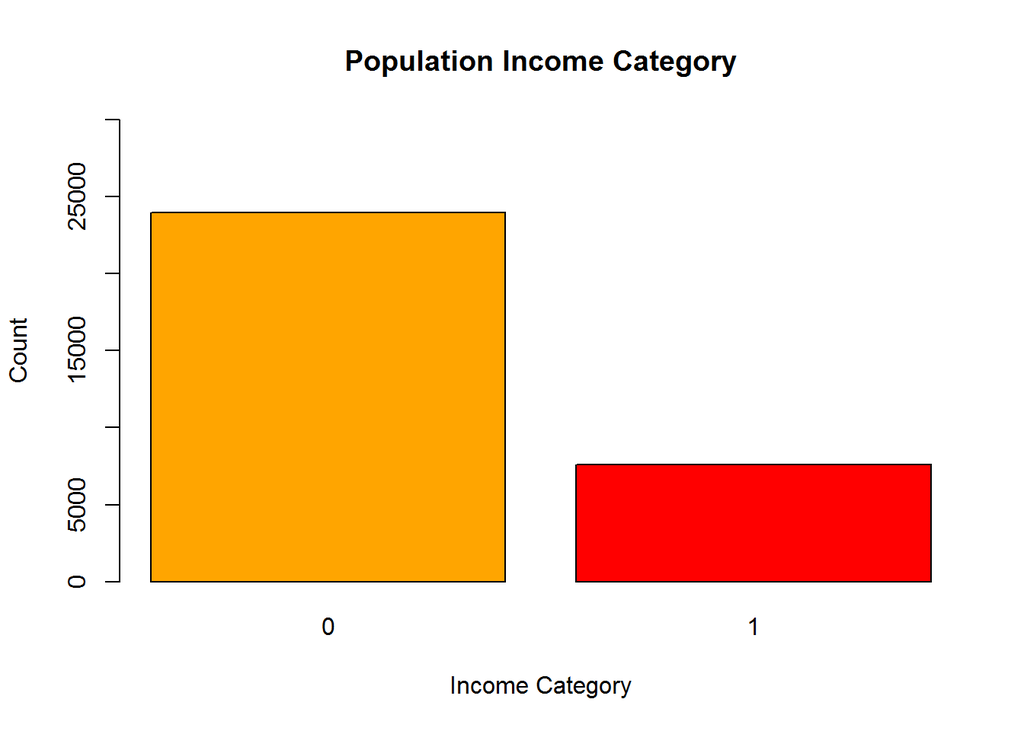

```r
barplot(table(population_dataset$target),
        main="Population Income Category",
        xlab="Income Category", ylab = "Count",
        col = c('orange','red'),
        ylim=c(0,30000))
```

- Have to do to stratified random sampling during split as the target variable is categirical and has class imbalance

# Data Pre-processing

- Checking for missing Values

```r
sum(is.na(population_dataset))
```

```
## [1] 33349
```

- Checking the number of missing values per column in the data frame

```r
colSums(is.na(population_dataset))
```

```
##              index                age     working_sector
##                  0                  2               1775
##   financial_weight      qualification years_of_education
##                  2                  2                  0
##           tax_paid         loan_taken     marital_status
##              29206                  0                  0
##         occupation       relationship          ethnicity
##               1782                  2                  2
##             gender               gain               loss
##                  2                  2                  2
##      working_hours            country             target
##                  2                568                  0
```

## Handling NA values

- There are four ways in which we can handle missing values:  
  **1.Deleting the observations for NA values.**  
  Observing NA values for minority class i.e for target = 1 (to take either of decision)

```r
colSums(is.na(population_dataset) & population_dataset$target == 1)
```

```
##              index                age     working_sector
##                  0                  2                185
##   financial_weight      qualification years_of_education
##                  2                  2                  0
##           tax_paid         loan_taken     marital_status
##               7044                  0                  0
##         occupation       relationship          ethnicity
##                185                  2                  2
##             gender               gain               loss
##                  2                  2                  2
##      working_hours            country             target
##                  2                141                  0
```

```
 Many records for minority class, thus should not be implemented
```

**2.Deleting the features (which should be avoided in early phase)**  
**3.Imputation with mean / median / mode (mean/median cannot be applied as there is categorical data)**

##### Columns having NA values:

- age: int
- working_sector: Factor w/ 7 levels
- financial_weight: int
- qualification: Factor w/ 16 levels
- tax_paid: num
- occupation: Factor w/ 14 levels
- relationship: Factor w/ 6 levels
- ethnicity: Factor w/ 5 levels
- gender: Factor w/ 2 levels
- gain: int
- loss: int
- working_hours: int
- country: Factor w/ 41 levels  
  **4.Prediction:** Prediction is most advanced method to impute your missing values and includes different approaches such as: kNN Imputation

#### KNN Imputation, k=179 (sqrt(n))

```r
population_dataset = knnImputation(population_dataset, k=179)
sum(is.na(population_dataset))
```

```
## [1] 0
```

0 NA values after imputation

## Train/Test Split

Split the data 70/30 into train and test sets by using Stratified Sampling and setting the seed as “770”  
Split the data using stratified sampling, we can do that by using the createDataPartition() function from the caret package

```r
population_dataset$target = as.factor(population_dataset$target)
set.seed(770)
# The argument "target" to the createDataPartition() function is the response variable
# The argument "p" is the percentage of data that goes to training
# The argument "list" should be input a boolean (T or F). Put list = F, else the output is going to be a list and your data can't be subsetted with it
train_rows = createDataPartition(population_dataset$target, p = 0.7, list = F)
train_data = population_dataset[train_rows,] #train data
test_data = population_dataset[-train_rows,] #test data
```

##### See the distribution of the target class in both train and test dataset

```r
table(train_data$target)
```

```
##
##     0     1
## 16778  5334
```

```r
table(test_data$target)
```

```
##
##    0    1
## 7190 2285
```

# Build a model

#### Basic Logistic Regression Model

*Use the glm() function to build a basic model*  
Building a model using all the variables, excluding the response variable, in the dataset

```r
log_reg <- glm(target~., data = train_data, family = binomial)
```

Get the summary of the model and understand the output

```r
summary(log_reg)
```

```
##
## Call:
## glm(formula = target ~ ., family = binomial, data = train_data)
##
## Deviance Residuals:
##     Min       1Q   Median       3Q      Max
## -5.1690  -0.5037  -0.1755  -0.0266   3.6306
##
## Coefficients:
##                                      Estimate Std. Error z value Pr(>|z|)
## (Intercept)                         3.769e+01  1.461e+03   0.026 0.979413
## index                               1.811e-06  2.342e-06   0.773 0.439283
## age                                 2.511e-02  2.001e-03  12.548  < 2e-16
## working_sectornational              7.295e-01  1.367e-01   5.338 9.39e-08
## working_sectornot_worked           -7.293e-01  1.499e-01  -4.866 1.14e-06
## working_sectorprivate               1.953e-01  8.914e-02   2.191 0.028458
## working_sectorself_employed        -6.721e-03  1.037e-01  -0.065 0.948325
## working_sectorstate                -1.352e-01  1.318e-01  -1.026 0.304997
## working_sectorwithout_pay          -1.343e+01  3.723e+02  -0.036 0.971227
## financial_weight                    4.501e-07  2.100e-07   2.143 0.032116
## qualification 11th                  7.540e+00  2.434e+02   0.031 0.975292
## qualification 12th                  1.539e+01  4.869e+02   0.032 0.974785
## qualification 1st-4th              -3.186e+01  9.737e+02  -0.033 0.973896
## qualification 5th-6th              -2.279e+01  7.303e+02  -0.031 0.975107
## qualification 7th-8th              -1.563e+01  4.869e+02  -0.032 0.974394
## qualification 9th                  -7.671e+00  2.434e+02  -0.032 0.974861
## qualification Assoc-acdm            4.681e+01  1.461e+03   0.032 0.974435
## qualification Assoc-voc             3.933e+01  1.217e+03   0.032 0.974225
## qualification Bachelors             5.499e+01  1.704e+03   0.032 0.974257
## qualification Doctorate             7.870e+01  2.434e+03   0.032 0.974211
## qualification HS-grad               2.350e+01  7.303e+02   0.032 0.974335
## qualification Masters               6.299e+01  1.947e+03   0.032 0.974197
## qualification Preschool            -5.713e+01  1.228e+03  -0.047 0.962900
## qualification Prof-school           7.087e+01  2.191e+03   0.032 0.974197
## qualification Some-college          3.146e+01  9.737e+02   0.032 0.974227
## years_of_education                 -7.576e+00  2.434e+02  -0.031 0.975171
## tax_paid                            4.335e-05  3.825e-05   1.133 0.257058
## loan_taken                         -4.603e-02  1.034e-01  -0.445 0.656283
## marital_statusMarried-civilian      1.592e+00  3.480e-01   4.574 4.79e-06
## marital_statusMarried-defence       1.467e+00  7.089e-01   2.070 0.038452
```

[output cut: 166 more lines]

```
## country Thailand
## country Trinadad&Tobago
## country United-States
## country Vietnam
## country Yugoslavia
## ---
## Signif. codes:  0 '***' 0.001 '**' 0.01 '*' 0.05 '.' 0.1 ' ' 1
##
## (Dispersion parameter for binomial family taken to be 1)
##
##     Null deviance: 24433  on 22111  degrees of freedom
## Residual deviance: 13939  on 22012  degrees of freedom
## AIC: 14139
##
## Number of Fisher Scoring iterations: 14
```

# Creating an ROC plot

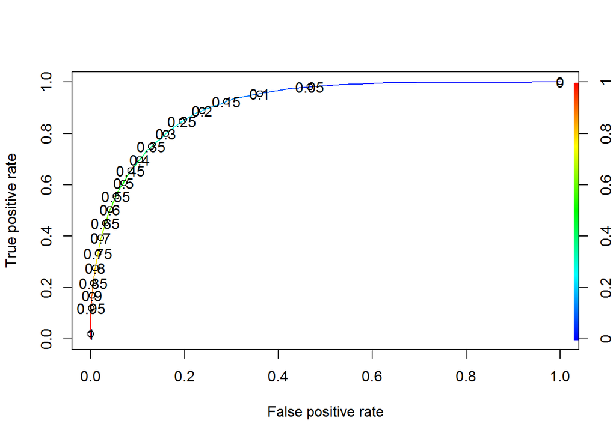

```r
prob_train = predict(log_reg, type = "response")
pred = prediction(prob_train, train_data$target)
perf = performance(pred, measure="tpr", x.measure="fpr")
plot(perf, col=rainbow(10), colorize=T, print.cutoffs.at=seq(0,1,0.05))
```

- Extract the AUC score of the ROC curve and store it in a variable named “auc”
- Use the performance() function on the prediction object created above using the ROCR package, to extract the AUC score

```r
perf_auc = performance(pred, measure="auc")
# Access the auc score from the performance object
auc = perf_auc@y.values[[1]]
print(auc)
```

```
## [1] 0.9094768
```

## Choose a Cutoff Value (hyper-parameter) VALIDATION

- Based on the trade off between TPR and FPR depending on the business domain, a call on the cutoff has to be made.

```r
prob_test = predict(log_reg, test_data, type = "response")
preds_test = ifelse(prob_test > 0.1, "1", "0")
preds_test = data.frame(preds_test)
confusionMatrix(preds_test$preds_test, test_data$target)
```

```
## Confusion Matrix and Statistics
##
##           Reference
## Prediction    0    1
##          0 4675  122
##          1 2515 2163
##
##                Accuracy : 0.7217
##                  95% CI : (0.7125, 0.7307)
##     No Information Rate : 0.7588
##     P-Value [Acc > NIR] : 1
##
##                   Kappa : 0.4397
##  Mcnemar's Test P-Value : <2e-16
##
##             Sensitivity : 0.6502
##             Specificity : 0.9466
##          Pos Pred Value : 0.9746
##          Neg Pred Value : 0.4624
##              Prevalence : 0.7588
##          Detection Rate : 0.4934
##    Detection Prevalence : 0.5063
##       Balanced Accuracy : 0.7984
##
##        'Positive' Class : 0
##
```

```r
#Accuracy : 0.7217 Kappa : 0.4397
```

```r
prob_test = predict(log_reg, test_data, type = "response")
preds_test = ifelse(prob_test > 0.2, "1", "0")
preds_test = data.frame(preds_test)
confusionMatrix(preds_test$preds_test, test_data$target)
```

```
## Confusion Matrix and Statistics
##
##           Reference
## Prediction    0    1
##          0 5523  286
##          1 1667 1999
##
##                Accuracy : 0.7939
##                  95% CI : (0.7856, 0.802)
##     No Information Rate : 0.7588
##     P-Value [Acc > NIR] : 2.73e-16
##
##                   Kappa : 0.5331
##  Mcnemar's Test P-Value : < 2.2e-16
##
##             Sensitivity : 0.7682
##             Specificity : 0.8748
##          Pos Pred Value : 0.9508
##          Neg Pred Value : 0.5453
##              Prevalence : 0.7588
##          Detection Rate : 0.5829
##    Detection Prevalence : 0.6131
##       Balanced Accuracy : 0.8215
##
##        'Positive' Class : 0
##
```

```r
#Accuracy : 0.7939 Kappa : 0.5331
```

```r
prob_test = predict(log_reg, test_data, type = "response")
preds_test = ifelse(prob_test > 0.25, "1", "0")
preds_test = data.frame(preds_test)
confusionMatrix(preds_test$preds_test, test_data$target)
```

```
## Confusion Matrix and Statistics
##
##           Reference
## Prediction    0    1
##          0 5831  403
##          1 1359 1882
##
##                Accuracy : 0.814
##                  95% CI : (0.8061, 0.8218)
##     No Information Rate : 0.7588
##     P-Value [Acc > NIR] : < 2.2e-16
##
##                   Kappa : 0.5554
##  Mcnemar's Test P-Value : < 2.2e-16
##
##             Sensitivity : 0.8110
##             Specificity : 0.8236
##          Pos Pred Value : 0.9354
##          Neg Pred Value : 0.5807
##              Prevalence : 0.7588
##          Detection Rate : 0.6154
##    Detection Prevalence : 0.6579
##       Balanced Accuracy : 0.8173
##
##        'Positive' Class : 0
##
```

```r
#Accuracy : 0.814 Kappa : 0.5554
```

```r
prob_test = predict(log_reg, test_data, type = "response")
preds_test = ifelse(prob_test > 0.3, "1", "0")
preds_test = data.frame(preds_test)
confusionMatrix(preds_test$preds_test, test_data$target)
```

```
## Confusion Matrix and Statistics
##
##           Reference
## Prediction    0    1
##          0 6109  511
##          1 1081 1774
##
##                Accuracy : 0.832
##                  95% CI : (0.8243, 0.8395)
##     No Information Rate : 0.7588
##     P-Value [Acc > NIR] : < 2.2e-16
##
##                   Kappa : 0.5769
##  Mcnemar's Test P-Value : < 2.2e-16
##
##             Sensitivity : 0.8497
##             Specificity : 0.7764
##          Pos Pred Value : 0.9228
##          Neg Pred Value : 0.6214
##              Prevalence : 0.7588
##          Detection Rate : 0.6447
##    Detection Prevalence : 0.6987
##       Balanced Accuracy : 0.8130
##
##        'Positive' Class : 0
##
```

```r
#Accuracy :  0.832 Kappa : 0.5769
```

```r
prob_test = predict(log_reg, test_data, type = "response")
preds_test = ifelse(prob_test > 0.35, "1", "0")
preds_test = data.frame(preds_test)
confusionMatrix(preds_test$preds_test, test_data$target)
```

```
## Confusion Matrix and Statistics
##
##           Reference
## Prediction    0    1
##          0 6322  626
##          1  868 1659
##
##                Accuracy : 0.8423
##                  95% CI : (0.8348, 0.8496)
##     No Information Rate : 0.7588
##     P-Value [Acc > NIR] : < 2.2e-16
##
##                   Kappa : 0.5842
##  Mcnemar's Test P-Value : 4.516e-10
##
##             Sensitivity : 0.8793
##             Specificity : 0.7260
##          Pos Pred Value : 0.9099
##          Neg Pred Value : 0.6565
##              Prevalence : 0.7588
##          Detection Rate : 0.6672
##    Detection Prevalence : 0.7333
##       Balanced Accuracy : 0.8027
##
##        'Positive' Class : 0
##
```

```r
#Accuracy : 0.8423 Kappa : 0.5842
```

```r
prob_test = predict(log_reg, test_data, type = "response")
preds_test = ifelse(prob_test > 0.4, "1", "0")
preds_test = data.frame(preds_test)
confusionMatrix(preds_test$preds_test, test_data$target)
```

```
## Confusion Matrix and Statistics
##
##           Reference
## Prediction    0    1
##          0 6500  737
##          1  690 1548
##
##                Accuracy : 0.8494
##                  95% CI : (0.842, 0.8565)
##     No Information Rate : 0.7588
##     P-Value [Acc > NIR] : <2e-16
##
##                   Kappa : 0.5856
##  Mcnemar's Test P-Value : 0.2233
##
##             Sensitivity : 0.9040
##             Specificity : 0.6775
##          Pos Pred Value : 0.8982
##          Neg Pred Value : 0.6917
##              Prevalence : 0.7588
##          Detection Rate : 0.6860
##    Detection Prevalence : 0.7638
##       Balanced Accuracy : 0.7907
##
##        'Positive' Class : 0
##
```

```r
#Accuracy : 0.8494 Kappa : 0.5856
```

```r
prob_test = predict(log_reg, test_data, type = "response")
preds_test = ifelse(prob_test > 0.45, "1", "0")
preds_test = data.frame(preds_test)
confusionMatrix(preds_test$preds_test, test_data$target)
```

```
## Confusion Matrix and Statistics
##
##           Reference
## Prediction    0    1
##          0 6633  852
##          1  557 1433
##
##                Accuracy : 0.8513
##                  95% CI : (0.844, 0.8584)
##     No Information Rate : 0.7588
##     P-Value [Acc > NIR] : < 2.2e-16
##
##                   Kappa : 0.575
##  Mcnemar's Test P-Value : 4.789e-15
##
##             Sensitivity : 0.9225
##             Specificity : 0.6271
##          Pos Pred Value : 0.8862
##          Neg Pred Value : 0.7201
##              Prevalence : 0.7588
##          Detection Rate : 0.7001
##    Detection Prevalence : 0.7900
##       Balanced Accuracy : 0.7748
##
##        'Positive' Class : 0
##
```

```r
#Accuracy : 0.8513 Kappa : 0.575
```

- A cutoff of 0.45 can be chosen

### Feature Engineering

- Droping least significant columns

```r
population_dataset = subset(population_dataset,
                            select =
                              -c(qualification,country,ethnicity))
```

### Convert the index column to the row names, as this is unique

```r
rownames(population_dataset) = population_dataset$index
#Drop the index column
population_dataset$index = NULL
```

```r
CategoricalCol = function(x){
  as.factor(population_dataset[,x])
}
ColNames = c("loan_taken")
population_dataset[,ColNames] = lapply(ColNames, CategoricalCol)
```

# Rebuilding the model after Feature Engineering

## Train/Test Split

```r
set.seed(770)
train_rows = createDataPartition(population_dataset$target, p = 0.7, list = F)
train_data = population_dataset[train_rows,] #train data
test_data = population_dataset[-train_rows,] #test data
```

```r
log_reg = glm(target~., data = train_data, family = binomial)
```

# Calculating AUC after Feature Engineering

```r
prob_train = predict(log_reg, type = "response")
pred = prediction(prob_train, train_data$target)

perf_auc = performance(pred, measure="auc")
# Access the auc score from the performance object
auc = perf_auc@y.values[[1]]
print(auc)
```

```
## [1] 0.9077456
```

# VALIDATION (for a cutoff of 0.45)

```r
prob_test = predict(log_reg, test_data, type = "response")
preds_test = ifelse(prob_test > 0.45, "1", "0")
preds_test = data.frame(preds_test)
confusionMatrix(preds_test$preds_test, test_data$target)
```

```
## Confusion Matrix and Statistics
##
##           Reference
## Prediction    0    1
##          0 6628  851
##          1  562 1434
##
##                Accuracy : 0.8509
##                  95% CI : (0.8435, 0.858)
##     No Information Rate : 0.7588
##     P-Value [Acc > NIR] : < 2.2e-16
##
##                   Kappa : 0.5742
##  Mcnemar's Test P-Value : 1.836e-14
##
##             Sensitivity : 0.9218
##             Specificity : 0.6276
##          Pos Pred Value : 0.8862
##          Neg Pred Value : 0.7184
##              Prevalence : 0.7588
##          Detection Rate : 0.6995
##    Detection Prevalence : 0.7893
##       Balanced Accuracy : 0.7747
##
##        'Positive' Class : 0
##
```

```r
#Accuracy : 0.8509 Kappa : 0.5742
```

# Model Accuracy

#### Accuracy : 0.8509

#### Kappa : 0.5742

# Applying model on given Test Data (unseen data) to predict

```r
test_dataset = read.csv("test_data.csv")
test_dataset = subset(test_dataset,
                            select =
                              -c(qualification,country,ethnicity))

rownames(test_dataset) <- test_dataset$index
#Drop the index column
test_dataset$index = NULL
test_dataset <-knnImputation(test_dataset , k=33, meth = "median")


CategoricalCol = function(x){
  as.factor(test_dataset[,x])
}
ColNames = c("loan_taken")
test_dataset[,ColNames] = lapply(ColNames, CategoricalCol)

#Applying regression on Test Data (unseen data) to predict
prob_test <- predict(log_reg, test_dataset, type = "response")
head(prob_test)
```

```
##       31588       31589       31590       31591       31592       31593
## 0.019885484 0.017683660 0.575841093 0.142455409 0.006186795 0.045781140
```

```r
ApproxPredict = ifelse(prob_test > 0.45, "1", "0")
ApproxPredict = data.frame(ApproxPredict)
print(ApproxPredict)
```

```
##       ApproxPredict
## 31588             0
## 31589             0
## 31590             1
## 31591             0
## 31592             0
## 31593             0
## 31594             1
## 31595             0
## 31596             1
## 31597             0
## 31598             0
## 31599             0
## 31600             0
## 31601             0
```

[output cut: 962 more lines]

# Using Naive Bayes for Machine Learning Predictions

### Read and Understand the Data

- Irrelevant columns to be dropped

```r
population_dataset = read.csv("train_data.csv")
rownames(population_dataset) <- population_dataset$index
#Drop the index column
population_dataset$index = NULL

population_dataset = subset(population_dataset,
                            select =
                              -c(qualification,country,ethnicity,tax_paid))
```

## Convert the attributes to appropriate types

- For the Naive Bayes implementation in the e1071 package, we have to send in our data in a categorical format, so we have to make the appropriate data type coversions.

```r
population_dataset$age = ifelse( population_dataset$age>=1 &
                           population_dataset$age<=20, "Young",
                         ifelse(population_dataset$age>=21 &
                                  population_dataset$age<=40, "Mature",
                                ifelse(population_dataset$age>=41 &
                                         population_dataset$age<=60, "Old",
                                       "Retired")))
population_dataset$marital_status =
  ifelse( population_dataset$marital_status
          %in% c("Divorced", "Never-married", "Separated","Widowed"),"Single",
  ifelse(population_dataset$marital_status
         %in% c("Married-defence","Married-civilian","Married-non-resident"), "Married",""))

head(population_dataset)
```

```
##      age working_sector financial_weight years_of_education loan_taken
## 1 Mature          state            77516                 13          0
## 2    Old  self_employed            83311                 13          0
## 3 Mature        private           215646                  9          0
## 4    Old        private           234721                  7          0
## 5 Mature        private           338409                 13          0
## 6 Mature        private           284582                 14          0
##   marital_status occupation   relationship  gender gain loss working_hours
## 1         Single   clerical  Not-in-family    Male 2174    0            40
## 2        Married managerial        Husband    Male    0    0            13
## 3         Single    cleaner  Not-in-family    Male    0    0            40
## 4        Married    cleaner        Husband    Male    0    0            40
## 5        Married  specialty           Wife  Female    0    0            40
## 6        Married managerial           Wife  Female    0    0            40
##   target
## 1      0
## 2      0
## 3      0
## 4      0
## 5      0
## 6      0
```

```r
population_dataset$financial_weight =
  ifelse( population_dataset$financial_weight>=1
          & population_dataset$financial_weight<=494901, "financelevel1",
  ifelse(population_dataset$financial_weight>=494902
         & population_dataset$financial_weight<=989808, "financelevel2", "financelevel3"))

population_dataset$years_of_education =
  ifelse( population_dataset$years_of_education>=1
          & population_dataset$years_of_education<=4, "edulevel1",
  ifelse(population_dataset$years_of_education>=5
          & population_dataset$years_of_education<=8, "edulevel2",
   ifelse(population_dataset$years_of_education>=9
          & population_dataset$years_of_education<=12,"edulevel3",
          "edulevel4")))

population_dataset$gain =
  ifelse( population_dataset$gain>=1
          & population_dataset$gain<=1409, "gainlevel1",
  ifelse(population_dataset$gain>=1410
          & population_dataset$gain<=2062, "gainlevel2",
  ifelse(population_dataset$gain>=2063
          & population_dataset$gain<=2414,"gainlevel3",
  ifelse( population_dataset$gain>=2415
          & population_dataset$gain<=2964, "gainlevel4",
  ifelse(population_dataset$gain>=2965
          & population_dataset$gain<=3471, "gainlevel5",
  ifelse(population_dataset$gain>=3472
          & population_dataset$gain<=4650,"gainlevel6",
          ifelse( population_dataset$gain>=4651
          & population_dataset$gain<=6097, "gainlevel7",
  ifelse(population_dataset$gain>=6098
          & population_dataset$gain<=7896, "gainlevel8",
  ifelse(population_dataset$gain>=7897
          & population_dataset$gain<=15020,"gainlevel9","gainlevel10")))))))))

population_dataset$loss =
  ifelse( population_dataset$loss>=1
          & population_dataset$loss<=1138, "losslevel1",
  ifelse(population_dataset$loss>=1139
          & population_dataset$loss<=1590, "losslevel2",
  ifelse(population_dataset$loss>=1591
          & population_dataset$loss<=1726,"losslevel3",
  ifelse( population_dataset$loss>=1727
          & population_dataset$loss<=1902, "losslevel4",
  ifelse(population_dataset$loss>=1903
          & population_dataset$loss<=2149, "losslevel5",
  ifelse(population_dataset$loss>=2150
          & population_dataset$loss<=2282,"losslevel6",
          ifelse( population_dataset$loss>=2283
          & population_dataset$loss<=2559, "losslevel7","losslevel8")))))))

population_dataset$working_hours =
  ifelse( population_dataset$working_hours>=1
          & population_dataset$working_hours<=10, "working_hourslevel1",
  ifelse(population_dataset$working_hours>=11
          & population_dataset$working_hours<=20, "working_hourslevel2",
  ifelse(population_dataset$working_hours>=21
          & population_dataset$working_hours<=30,"working_hourslevel3",
  ifelse( population_dataset$working_hours>=31
          & population_dataset$working_hours<=40, "working_hourslevel4",
  ifelse(population_dataset$working_hours>=41
          & population_dataset$working_hours<=50, "working_hourslevel5",
  ifelse(population_dataset$working_hours>=51
          & population_dataset$working_hours<=60,"working_hourslevel6",
          ifelse( population_dataset$working_hours>=61
          & population_dataset$working_hours<=70, "working_hourslevel7",
  ifelse(population_dataset$working_hours>=71
          & population_dataset$working_hours<=80, "working_hourslevel8",
  ifelse(population_dataset$working_hours>=81
          & population_dataset$working_hours<=90,"working_hourslevel9",
         "working_hourslevel10")))))))))


CategoricalCol = function(x){
  as.factor(population_dataset[,x])
}
ColNames = c("loan_taken","marital_status","age",
             "financial_weight","years_of_education",
             "gain","loss","working_hours","target")
population_dataset[,ColNames] = lapply(ColNames, CategoricalCol)

str(population_dataset)
```

```
## 'data.frame':    31587 obs. of  13 variables:
##  $ age               : Factor w/ 4 levels "Mature","Old",..: 1 2 1 2 1 1 2 2 1 2 ...
##  $ working_sector    : Factor w/ 7 levels "local_body","national",..: 6 5 4 4 4 4 4 5 4 4 ...
##  $ financial_weight  : Factor w/ 3 levels "financelevel1",..: 1 1 1 1 1 1 1 1 1 1 ...
##  $ years_of_education: Factor w/ 4 levels "edulevel1","edulevel2",..: 4 4 3 2 4 4 2 3 4 4 ...
##  $ loan_taken        : Factor w/ 2 levels "0","1": 1 1 1 1 1 1 1 2 1 1 ...
##  $ marital_status    : Factor w/ 2 levels "Married","Single": 2 1 2 1 1 1 1 1 2 1 ...
##  $ occupation        : Factor w/ 14 levels "cleaner","clerical",..: 2 8 1 1 12 8 9 8 12 8 ...
##  $ relationship      : Factor w/ 6 levels " Husband"," Not-in-family",..: 2 1 2 1 6 6 2 1 2 1 ...
##  $ gender            : Factor w/ 2 levels " Female"," Male": 2 2 2 2 1 1 1 2 1 2 ...
##  $ gain              : Factor w/ 10 levels "gainlevel1","gainlevel10",..: 4 2 2 2 2 2 2 2 10 8 ...
##  $ loss              : Factor w/ 8 levels "losslevel1","losslevel2",..: 8 8 8 8 8 8 8 8 8 8 ...
##  $ working_hours     : Factor w/ 10 levels "working_hourslevel1",..: 5 3 5 5 5 5 3 6 6 5 ...
##  $ target            : Factor w/ 2 levels "0","1": 1 1 1 1 1 1 1 2 2 2 ...
```

```r
train_rows = createDataPartition(population_dataset$target,p=0.7,list=F)
train = population_dataset[train_rows,]
test = population_dataset[-train_rows, ]
```

# Build the Naive Bayes Classifier

```r
library(e1071)
model_nb <- naiveBayes(train$target~., train)
print(model_nb)
```

```
##
## Naive Bayes Classifier for Discrete Predictors
##
## Call:
## naiveBayes.default(x = X, y = Y, laplace = laplace)
##
## A-priori probabilities:
## Y
##         0         1
## 0.7587735 0.2412265
##
## Conditional probabilities:
##    age
## Y         Mature          Old      Retired        Young
##   0 0.5495887472 0.2819167958 0.0725354631 0.0959589939
##   1 0.3940360090 0.5354463616 0.0703300825 0.0001875469
##
##    working_sector
## Y     local_body     national   not_worked      private self_employed
##   0 0.0649234694 0.0264668367 0.0003188776 0.7685586735  0.0991709184
##   1 0.0764649376 0.0501440922 0.0000000000 0.6497598463  0.1752161383
##    working_sector
## Y          state  without_pay
##   0 0.0399872449 0.0005739796
##   1 0.0484149856 0.0000000000
##
##    financial_weight
## Y   financelevel1 financelevel2 financelevel3
##   0  0.9869471928  0.0125759924  0.0004768149
##   1  0.9883720930  0.0112528132  0.0003750938
##
##    years_of_education
## Y     edulevel1   edulevel2   edulevel3   edulevel4
##   0 0.046370247 0.113303135 0.670401717 0.169924902
##   1 0.007124109 0.023622047 0.468503937 0.500749906
##
##    loan_taken
## Y            0          1
##   0 0.95124568 0.04875432
##   1 0.94994376 0.05005624
```

[output cut: 52 more lines]

```
## Y   working_hourslevel1 working_hourslevel10 working_hourslevel2
##   0         0.025032781          0.003576112         0.082906187
##   1         0.008252063          0.004126032         0.016129032
##    working_hours
## Y   working_hourslevel3 working_hourslevel4 working_hourslevel5
##   0         0.089104780         0.569912981         0.146143760
##   1         0.018004501         0.466616654         0.297824456
##    working_hours
## Y   working_hourslevel6 working_hourslevel7 working_hourslevel8
##   0         0.057813804         0.015079270         0.007509834
##   1         0.140472618         0.030570143         0.014441110
##    working_hours
## Y   working_hourslevel9
##   0         0.002920491
##   1         0.003563391
```

# Measure the Model Performace on test data

- Use the confusionMatrix() function from the caret package to look at the various performance metrics

```r
preds = predict(model_nb, test)
confusionMatrix(data = preds, reference = test$target, positive = "1")
```

```
## Confusion Matrix and Statistics
##
##           Reference
## Prediction    0    1
##          0 6008  568
##          1 1182 1717
##
##                Accuracy : 0.8153
##                  95% CI : (0.8073, 0.8231)
##     No Information Rate : 0.7588
##     P-Value [Acc > NIR] : < 2.2e-16
##
##                   Kappa : 0.5377
##  Mcnemar's Test P-Value : < 2.2e-16
##
##             Sensitivity : 0.7514
##             Specificity : 0.8356
##          Pos Pred Value : 0.5923
##          Neg Pred Value : 0.9136
##              Prevalence : 0.2412
##          Detection Rate : 0.1812
##    Detection Prevalence : 0.3060
##       Balanced Accuracy : 0.7935
##
##        'Positive' Class : 1
##
```

# Model Accuracy

#### Accuracy : 0.8153

#### Kappa : 0.5377

# Applying model on given Test Data (unseen data) to predict

```r
test = read.csv("test_data.csv")
rownames(test) = test$index
#Drop the index column
test$index = NULL
test = subset(test, select = -c(qualification,country,ethnicity,tax_paid))

test$age = ifelse( test$age>=1 &
                           test$age<=20, "Young",
                         ifelse(test$age>=21 &
                                  test$age<=40, "Mature",
                                ifelse(test$age>=41 &
                                         test$age<=60, "Old",
                                       "Retired")))
test$marital_status =
  ifelse( test$marital_status
          %in% c("Divorced", "Never-married", "Separated","Widowed"),"Single",
  ifelse(test$marital_status
         %in% c("Married-defence","Married-civilian","Married-non-resident"), "Married",""))

head(test)
```

```
##           age working_sector financial_weight years_of_education
## 31588  Mature        private           183175                 10
## 31589  Mature     local_body           115585                 10
## 31590  Mature        private           254202                 13
## 31591 Retired  self_employed           494223                 10
## 31592  Mature        private           253814                  9
## 31593  Mature        private           286370                  4
##       loan_taken marital_status occupation   relationship  gender gain
## 31588          1         Single   clerical  Not-in-family  Female    0
## 31589          0         Single    cleaner  Not-in-family    Male    0
## 31590          0        Married      sales        Husband    Male    0
## 31591          0         Single      sales      Unmarried    Male    0
## 31592          0        Married      sales      Unmarried  Female    0
## 31593          0        Married  inspector        Husband    Male    0
##       loss working_hours
## 31588    0            40
## 31589    0            50
## 31590    0            50
## 31591 1816             2
## 31592    0            25
## 31593    0            40
```

```r
test$financial_weight =
  ifelse( test$financial_weight>=1
          & test$financial_weight<=494901, "financelevel1",
  ifelse(test$financial_weight>=494902
         & test$financial_weight<=989808, "financelevel2", "financelevel3"))

test$years_of_education =
  ifelse( test$years_of_education>=1
          & test$years_of_education<=4, "edulevel1",
  ifelse(test$years_of_education>=5
          & test$years_of_education<=8, "edulevel2",
   ifelse(test$years_of_education>=9
          & test$years_of_education<=12,"edulevel3",
          "edulevel4")))

test$gain =
  ifelse( test$gain>=1
          & test$gain<=1409, "gainlevel1",
  ifelse(test$gain>=1410
          & test$gain<=2062, "gainlevel2",
  ifelse(test$gain>=2063
          & test$gain<=2414,"gainlevel3",
  ifelse( test$gain>=2415
          & test$gain<=2964, "gainlevel4",
  ifelse(test$gain>=2965
          & test$gain<=3471, "gainlevel5",
  ifelse(test$gain>=3472
          & test$gain<=4650,"gainlevel6",
          ifelse( test$gain>=4651
          & test$gain<=6097, "gainlevel7",
  ifelse(test$gain>=6098
          & test$gain<=7896, "gainlevel8",
  ifelse(test$gain>=7897
          & test$gain<=15020,"gainlevel9","gainlevel10")))))))))

test$loss =
  ifelse( test$loss>=1
          & test$loss<=1138, "losslevel1",
  ifelse(test$loss>=1139
          & test$loss<=1590, "losslevel2",
  ifelse(test$loss>=1591
          & test$loss<=1726,"losslevel3",
  ifelse( test$loss>=1727
          & test$loss<=1902, "losslevel4",
  ifelse(test$loss>=1903
          & test$loss<=2149, "losslevel5",
  ifelse(test$loss>=2150
          & test$loss<=2282,"losslevel6",
          ifelse( test$loss>=2283
          & test$loss<=2559, "losslevel7","losslevel8")))))))

test$working_hours =
  ifelse( test$working_hours>=1
          & test$working_hours<=10, "working_hourslevel1",
  ifelse(test$working_hours>=11
          & test$working_hours<=20, "working_hourslevel2",
  ifelse(test$working_hours>=21
          & test$working_hours<=30,"working_hourslevel3",
  ifelse( test$working_hours>=31
          & test$working_hours<=40, "working_hourslevel4",
  ifelse(test$working_hours>=41
          & test$working_hours<=50, "working_hourslevel5",
  ifelse(test$working_hours>=51
          & test$working_hours<=60,"working_hourslevel6",
          ifelse( test$working_hours>=61
          & test$working_hours<=70, "working_hourslevel7",
  ifelse(test$working_hours>=71
          & test$working_hours<=80, "working_hourslevel8",
  ifelse(test$working_hours>=81
          & test$working_hours<=90,"working_hourslevel9",
         "working_hourslevel10")))))))))


CategoricalCol = function(x){
  as.factor(test[,x])
}
ColNames = c("loan_taken","marital_status","age",
             "financial_weight","years_of_education",
             "gain","loss","working_hours")
test[,ColNames] = lapply(ColNames, CategoricalCol)

ApproxPredict = predict(model_nb, test)
ApproxPredict = data.frame(ApproxPredict)
print(ApproxPredict)
```

```
##     ApproxPredict
## 1               0
## 2               0
## 3               1
## 4               0
## 5               0
## 6               0
## 7               1
## 8               0
## 9               1
## 10              0
## 11              0
## 12              0
## 13              0
## 14              0
```

[output cut: 962 more lines]